# Credit Scoring

ELP

Fall 2017

We will use in this lab a dataset used in a competition at https://www.datascience.net. The aim is to assign a credit score `Y` to customer according to some characteristics. We will measure the performance of our methods with either the raw prediction error or the AUC (Area Under Curve) criterion.

We have at hands a training dataset of 5380 customers that we will use during the lab and a test dataset of 1345 customers that we will use only at the very end of the lab to test our methods against unseen customers.

The following table shows the description of the different variables as given in the *datascience.net* challenge.

| Variable | Content | Type |
| --- | --- | --- |
| BirthDate | Client birth date | Date |
| Customer_Open_Date | Arrival date of the client in the branch of the bank filial | Date |
| Customer_Type | Customer type (existing / new) | String |
| Educational_Level | Highest Degree | String |
| Id_Customer | Customer identifier | Numerical |
| Marital_Status | Martital status | String |
| Nb_Of_Products | Number of products detained by the customer at the decision date | Numerical |
| Net_Annual_Income | Annual income | Numerical |
| Number_Of_Dependant | Number of dependant | Numerical |
| P_Client | Intern categorization of the client | String |
| Prod_Category | Product category | String |
| Prod_Closed_Date | Closing date of the product | Date |
| Prod_Decision_Date | Decision date of the financing grant | Date |
| Prod_Sub_Category | Product subcategory | String |
| Source | Financing source (Branch / Sales) | String |
| Type_Of_Residence | Type of residence | String |
| Years_At_Business | Number of years in the current job | Numerical |
| Years_At_Residence | Number of years at the current residence place | Numerical |
| Y | Credit issue (to be predicted) | Numerical |

# Data frame formating

1. Read the training dataset **CreditTraing.csv** with `read_csv` and check it with `glimpse`.

```r
library("tidyverse")
CreditTraining <- read_csv("CreditTraining.csv",
                           locale = locale(decimal_mark = ","))
glimpse(CreditTraining)
```

```
## Observations: 5,380
## Variables: 19
## $ Id_Customer         <int> 7440, 573, 9194, 3016, 6524, 3858, 2189, 9...
## $ Y                   <int> 0, 0, 0, 1, 0, 0, 0, 0, 0, 1, 0, 0, 0, 0, ...
## $ Customer_Type       <chr> "Non Existing Client", "Existing Client", ...
## $ BirthDate           <chr> "07/08/1977", "13/06/1974", "07/11/1973", ...
## $ Customer_Open_Date  <chr> "13/02/2012", "04/02/2009", "03/04/2012", ...
## $ P_Client            <chr> "NP_Client", "P_Client", "NP_Client", "NP_...
## $ Educational_Level   <chr> "University", "University", "University", ...
## $ Marital_Status      <chr> "Married", "Married", "Married", "Married"...
## $ Number_Of_Dependant <int> 3, 0, 2, 3, 2, 0, 0, 0, 0, 4, 0, 0, 0, 0, ...
## $ Years_At_Residence  <int> 1, 12, 10, 3, 1, 28, 10, 15, 0, 35, 10, 10...
## $ Net_Annual_Income   <dbl> 36.000, 18.000, 36.000, 36.000, 36.000, 60...
## $ Years_At_Business   <int> 1, 2, 1, 1, 1, 2, 1, 1, 3, 2, 3, 2, 4, 1, ...
## $ Prod_Sub_Category   <chr> "C", "C", "C", "C", "C", "C", "C", "C", "P...
## $ Prod_Decision_Date  <chr> "14/02/2012", "30/06/2011", "04/04/2012", ...
## $ Source              <chr> "Sales", "Sales", "Sales", "Sales", "Sales...
## $ Type_Of_Residence   <chr> "Owned", "Parents", "Owned", "New rent", "...
## $ Nb_Of_Products      <int> 1, 1, 1, 1, 1, 1, 1, 1, 1, 1, 1, 2, 1, 1, ...
## $ Prod_Closed_Date    <chr> NA, NA, NA, "31/12/2012", NA, NA, NA, "16/...
## $ Prod_Category       <chr> "B", "G", "B", "L", "D", "C", "B", "B", "E...
```

```r
CreditTesting <- read_csv2("CreditTesting.csv")
glimpse(CreditTesting)
```

```
## Observations: 1,345
## Variables: 22
## $ Id_Customer         <int> 6714, 6092, 6945, 8556, 642, 6798, 7060, 1...
## $ Y                   <int> 0, 1, 0, 0, 0, 0, 0, 0, 1, 0, 1, 0, 0, 0, ...
## $ Customer_Type       <chr> "Non Existing Client", "Existing Client", ...
## $ BirthDate           <chr> "02/09/1971", "29/10/1988", "03/04/1968", ...
## $ Customer_Open_Date  <chr> "18/01/2012", "07/11/2010", "20/06/2006", ...
## $ P_Client            <chr> "NP_Client", "P_Client", "P_Client", "NP_C...
## $ Educational_Level   <chr> "University", "University", "University", ...
## $ Marital_Status      <chr> "Married", "Single", "Married", "Married",...
## $ Number_Of_Dependant <int> 3, 0, 0, 2, 3, 2, 0, 0, 1, 2, 2, 0, 4, 0, ...
## $ Years_At_Residence  <int> 10, 1, 10, 10, 25, 10, 10, 9, 26, 32, 2, 1...
## $ Net_Annual_Income   <dbl> 36.000, 59.916, 40.000, 36.000, 20.000, 36...
## $ Years_At_Business   <int> 3, 1, 10, 3, 1, 1, 3, 10, 2, 5, 2, 10, 1, ...
## $ Prod_Sub_Category   <chr> "C", "C", "G", "C", "C", "C", "C", "G", "C...
## $ Prod_Decision_Date  <chr> "23/01/2012", "04/01/2012", "23/02/2012", ...
## $ Source              <chr> "Sales", "Branch", "Branch", "Sales", "Sal...
## $ Type_Of_Residence   <chr> "Owned", "Owned", "Owned", "Owned", "Owned...
## $ Nb_Of_Products      <int> 1, 1, 1, 1, 1, 1, 1, 1, 1, 1, 1, 1, 1, 1, ...
## $ Prod_Closed_Date    <chr> NA, "28/06/2012", "24/02/2013", NA, NA, NA...
## $ Prod_Category       <chr> "B", "H", "B", "B", "B", "B", "B", "C", "L...
## $ X20                 <chr> NA, NA, NA, NA, NA, NA, NA, NA, NA, NA, NA...
## $ X21                 <chr> NA, NA, NA, NA, NA, NA, NA, NA, NA, NA, NA...
## $ X22                 <chr> NA, NA, NA, NA, NA, NA, NA, NA, NA, NA, NA...
```

2. Which variables are not well categorized and how to fix them by construction a function that can be reused for the final test dataset? We recommend the use of `dmy` from the package **lubridate** to convert the date in a POSIX compliant format…

```r
Fix_Type <- function(Credit) {
Credit <- dplyr::mutate(Credit, Id_Customer = factor(Id_Customer),
                        Y = factor(Y),
                        BirthDate = lubridate::dmy(BirthDate),
                        Customer_Open_Date = lubridate::dmy(Customer_Open_Date),
                         Prod_Decision_Date = lubridate::dmy(Prod_Decision_Date),
                        Prod_Closed_Date = lubridate::dmy(Prod_Closed_Date))
}
CreditTraining <- Fix_Type(CreditTraining)
CreditTesting <- Fix_Type(CreditTesting)
```

3. An overlooked details is the order of the levels in a factor. In particular, when using **ggplot2**, the first level of a binary variable corresponds to the color red while the second corresponds to the color green. Fix the variable `Y` and another variable for which the default alphanumeric order seems incorrect.

```r
summary(CreditTraining)
```

```
##   Id_Customer   Y        Customer_Type        BirthDate
##  1      :   1   0:4987   Length:5380        Min.   :1937-12-06
##  3      :   1   1: 393   Class :character   1st Qu.:1963-10-08
##  4      :   1            Mode  :character   Median :1973-10-07
##  6      :   1                               Mean   :1972-04-04
##  7      :   1                               3rd Qu.:1981-06-21
##  8      :   1                               Max.   :1990-11-07
##  (Other):5374
##  Customer_Open_Date     P_Client         Educational_Level
##  Min.   :1982-03-04   Length:5380        Length:5380
##  1st Qu.:2010-12-01   Class :character   Class :character
##  Median :2011-09-04   Mode  :character   Mode  :character
##  Mean   :2010-08-08
##  3rd Qu.:2011-12-26
##  Max.   :2012-04-26
##
##  Marital_Status     Number_Of_Dependant Years_At_Residence
##  Length:5380        Min.   : 0.000      Min.   : 0.00
##  Class :character   1st Qu.: 0.000      1st Qu.: 4.00
##  Mode  :character   Median : 0.000      Median :10.00
##                     Mean   : 1.059      Mean   :12.63
##                     3rd Qu.: 2.000      3rd Qu.:18.00
##                     Max.   :20.000      Max.   :70.00
##                     NA's   :2
##  Net_Annual_Income   Years_At_Business Prod_Sub_Category
##  Min.   :    0.004   Min.   : 0.000    Length:5380
##  1st Qu.:   20.000   1st Qu.: 1.000    Class :character
##  Median :   36.000   Median : 1.000    Mode  :character
##  Mean   :   61.182   Mean   : 4.266
##  3rd Qu.:   36.000   3rd Qu.: 4.000
##  Max.   :10000.000   Max.   :98.000
##  NA's   :2           NA's   :2
##  Prod_Decision_Date      Source          Type_Of_Residence
##  Min.   :2011-05-02   Length:5380        Length:5380
##  1st Qu.:2011-08-15   Class :character   Class :character
##  Median :2011-11-09   Mode  :character   Mode  :character
##  Mean   :2011-11-09
##  3rd Qu.:2012-02-09
##  Max.   :2012-04-28
##
##  Nb_Of_Products  Prod_Closed_Date     Prod_Category
##  Min.   :1.000   Min.   :2011-10-31   Length:5380
##  1st Qu.:1.000   1st Qu.:2012-07-31   Class :character
##  Median :1.000   Median :2012-11-29   Mode  :character
##  Mean   :1.089   Mean   :2012-11-19
##  3rd Qu.:1.000   3rd Qu.:2013-03-26
##  Max.   :3.000   Max.   :2013-06-02
##                  NA's   :4206
```

```r
Fix_Levels <- function(Credit) {
  Credit <- dplyr::mutate(Credit, Y = factor(Y, levels = c(1,0),
                                      labels = c("DEFAULT","NO_DEFAULT")),
                          Customer_Type = factor(Customer_Type,
                                                  levels = c("Non Existing Client", "Existing Client")),
                          Educational_Level = factor(Educational_Level,
                                            levels = c("Secondary or Less",
                                                       "Diploma",
                                                       "University",
                                                       "Master/PhD")))
}
CreditTraining <- Fix_Levels(CreditTraining)
CreditTesting <- Fix_Levels(CreditTesting)
```

4. We can now examine each variable individually to see if something is wrong.

```
##           Y
##  DEFAULT   : 393
##  NO_DEFAULT:4987
```

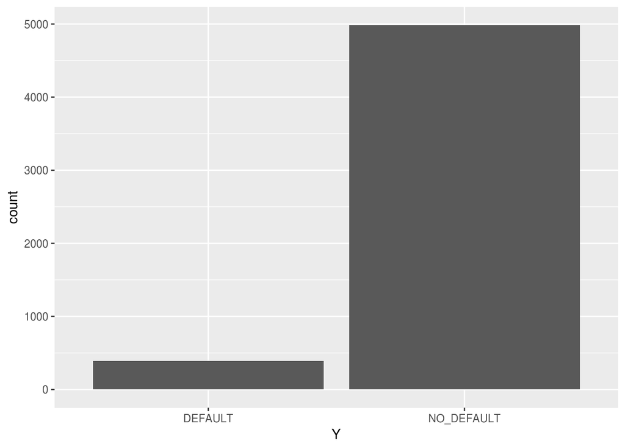

```
##              Customer_Type
##  Non Existing Client:3369
##  Existing Client    :2011
```

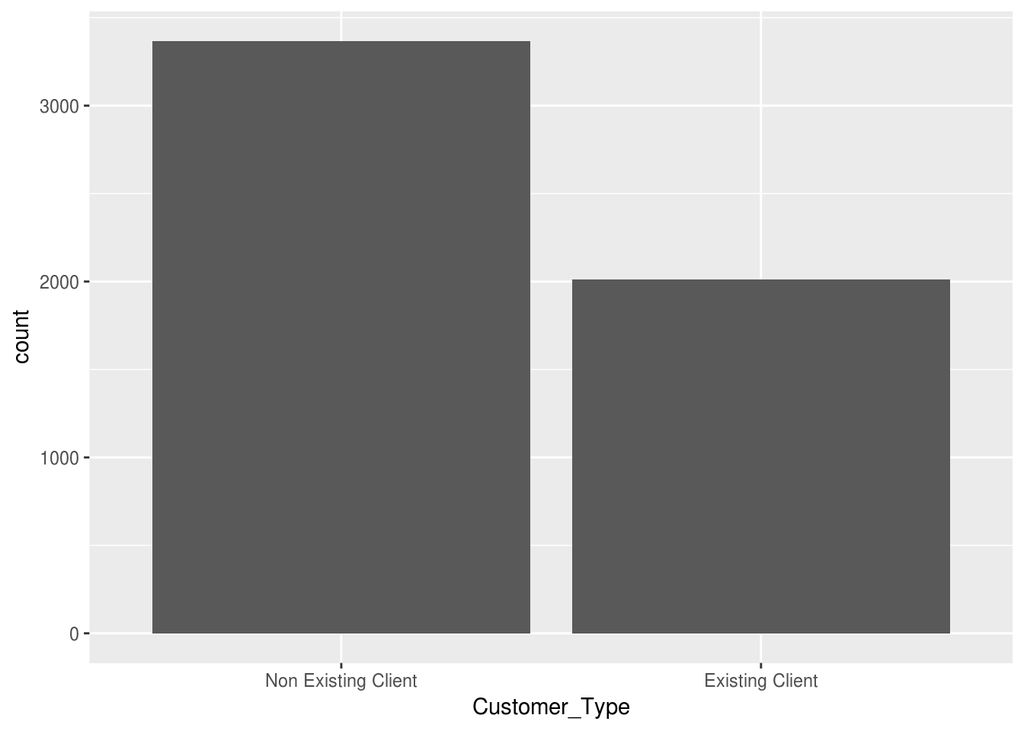

```
##    BirthDate
##  Min.   :1937-12-06
##  1st Qu.:1963-10-08
##  Median :1973-10-07
##  Mean   :1972-04-04
##  3rd Qu.:1981-06-21
##  Max.   :1990-11-07
```

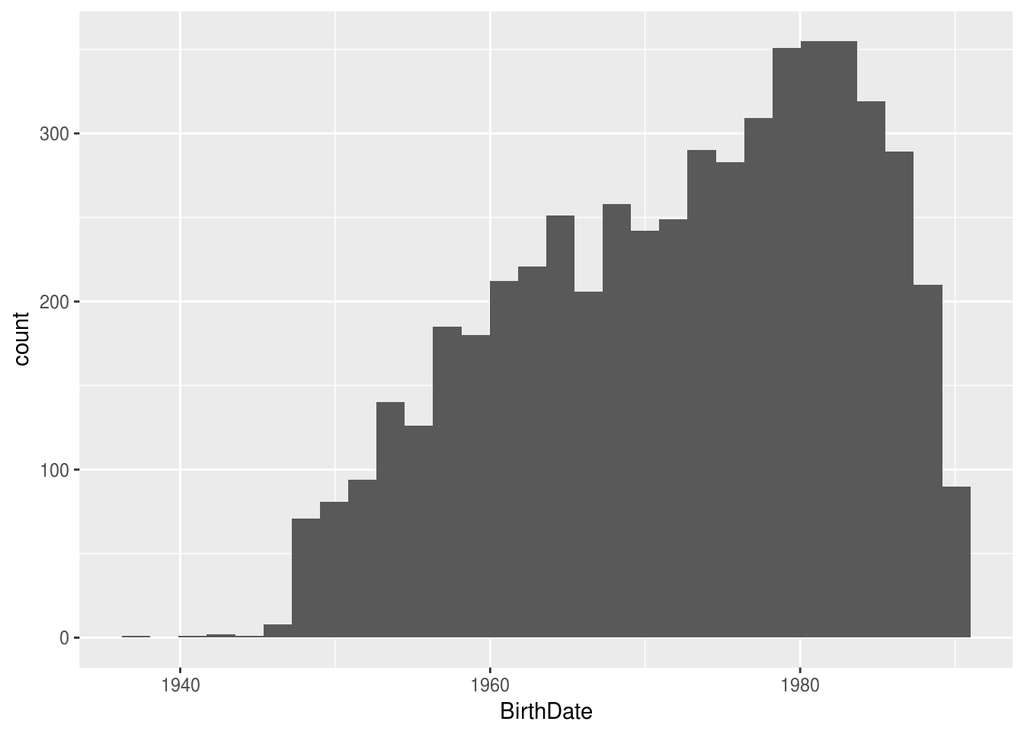

```
##  Customer_Open_Date
##  Min.   :1982-03-04
##  1st Qu.:2010-12-01
##  Median :2011-09-04
##  Mean   :2010-08-08
##  3rd Qu.:2011-12-26
##  Max.   :2012-04-26
```

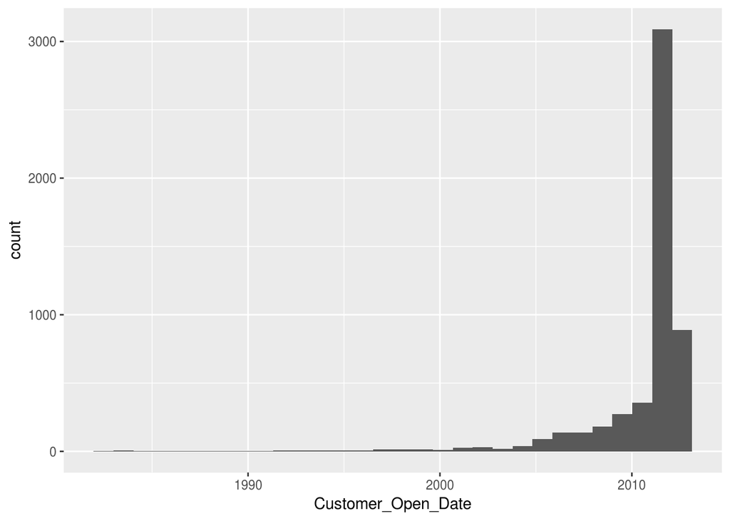

```
##    P_Client
##  Length:5380
##  Class :character
##  Mode  :character
```

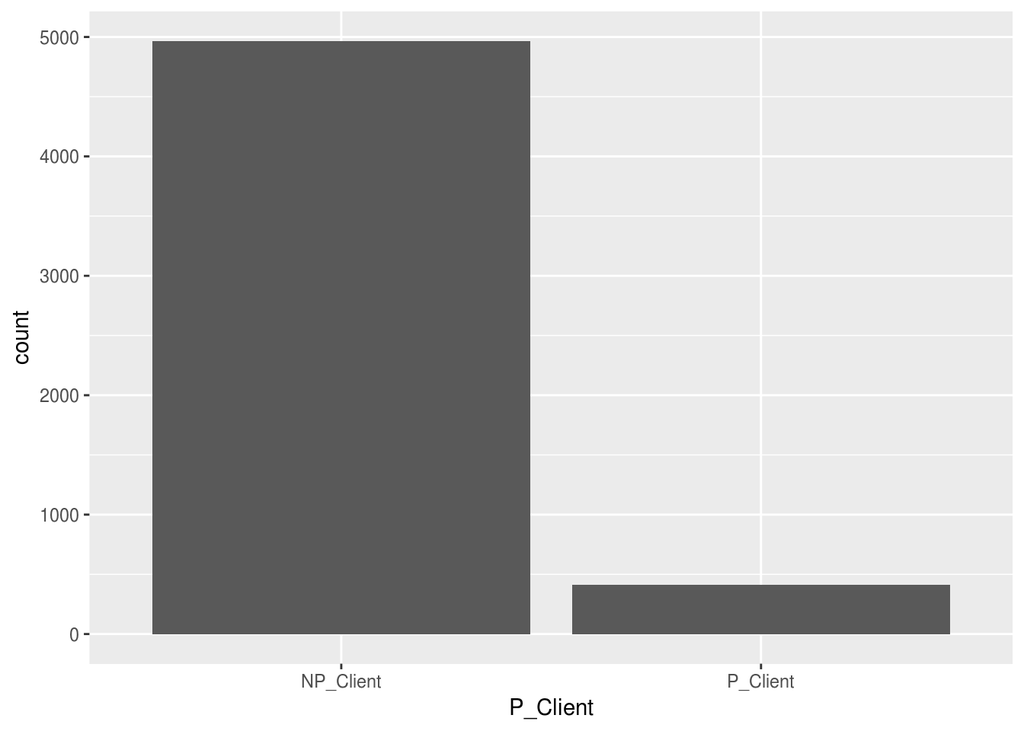

```
##          Educational_Level
##  Secondary or Less:  15
##  Diploma          :  58
##  University       :4785
##  Master/PhD       : 522
```

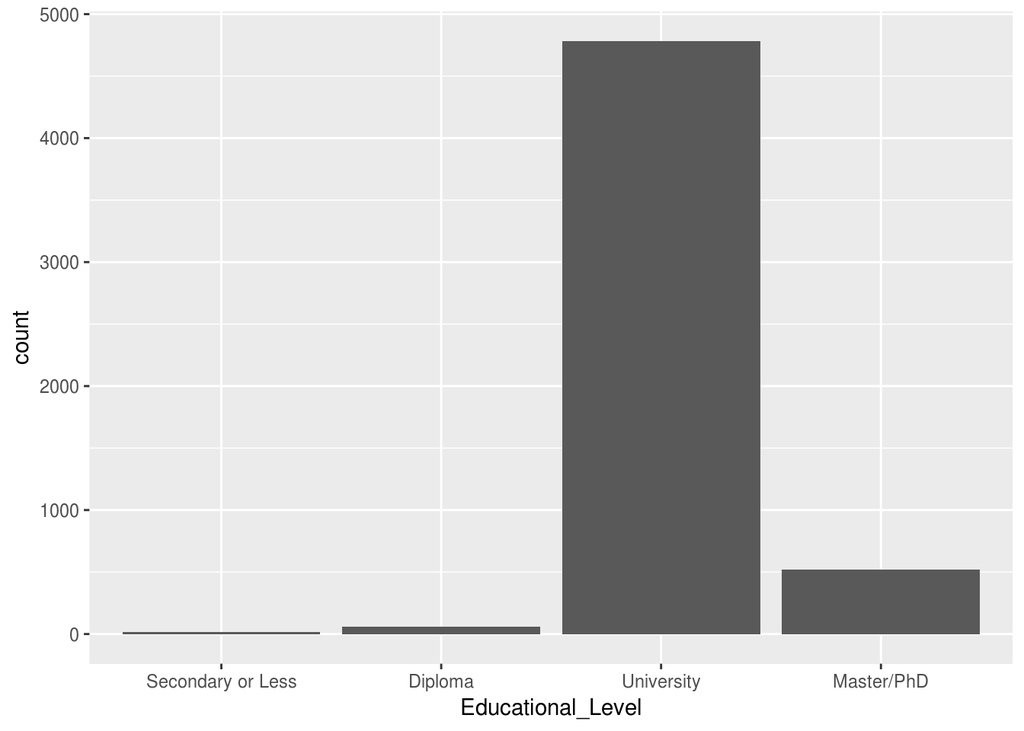

```
##  Marital_Status
##  Length:5380
##  Class :character
##  Mode  :character
```

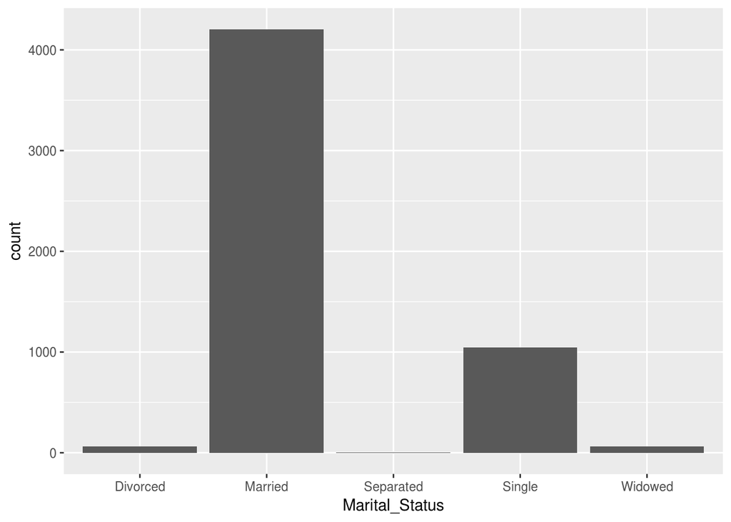

```
##  Number_Of_Dependant
##  Min.   : 0.000
##  1st Qu.: 0.000
##  Median : 0.000
##  Mean   : 1.059
##  3rd Qu.: 2.000
##  Max.   :20.000
##  NA's   :2
## Number_Of_Dependant has 2 NA
```

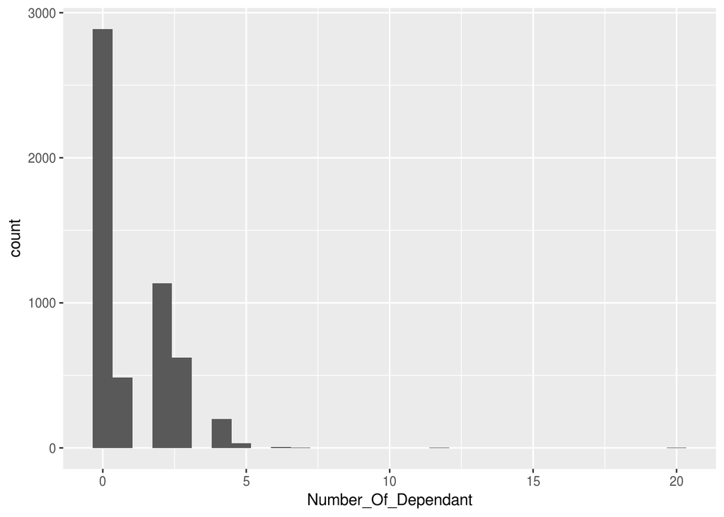

```
##  Years_At_Residence
##  Min.   : 0.00
##  1st Qu.: 4.00
##  Median :10.00
##  Mean   :12.63
##  3rd Qu.:18.00
##  Max.   :70.00
```

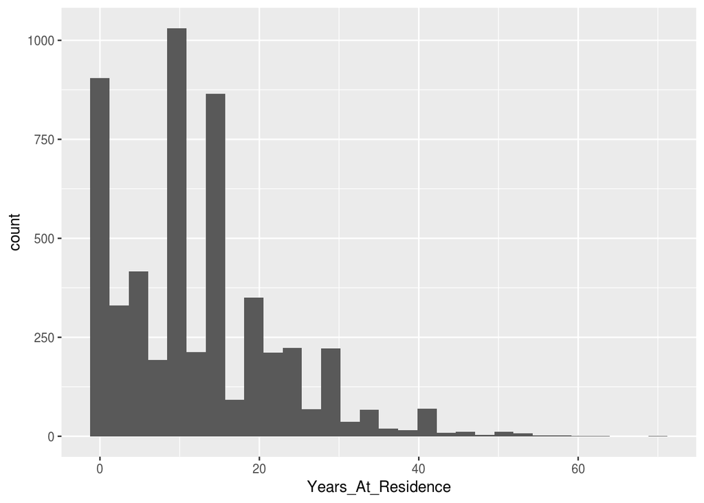

```
##  Net_Annual_Income
##  Min.   :    0.004
##  1st Qu.:   20.000
##  Median :   36.000
##  Mean   :   61.182
##  3rd Qu.:   36.000
##  Max.   :10000.000
##  NA's   :2
## Net_Annual_Income has 2 NA
```

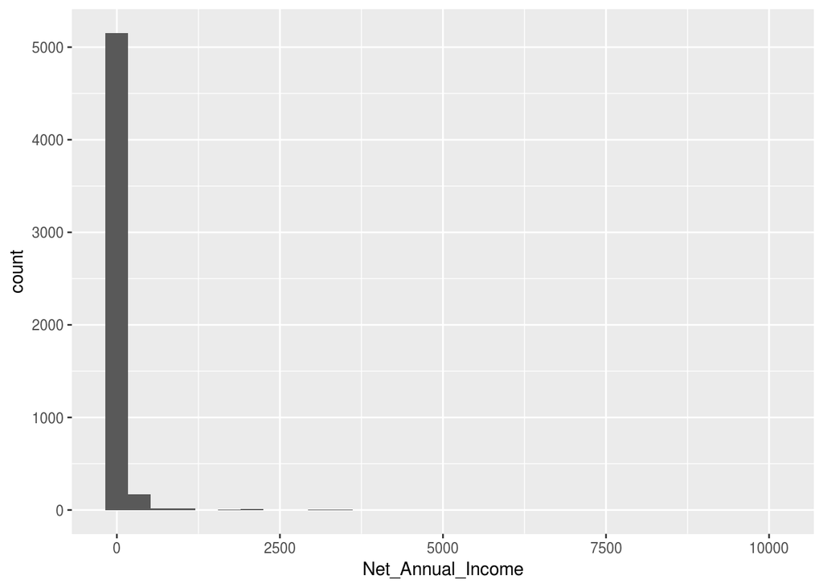

```
##  Years_At_Business
##  Min.   : 0.000
##  1st Qu.: 1.000
##  Median : 1.000
##  Mean   : 4.266
##  3rd Qu.: 4.000
##  Max.   :98.000
##  NA's   :2
## Years_At_Business has 2 NA
```

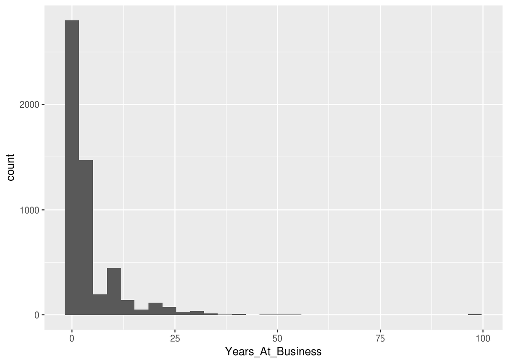

```
##  Prod_Sub_Category
##  Length:5380
##  Class :character
##  Mode  :character
```

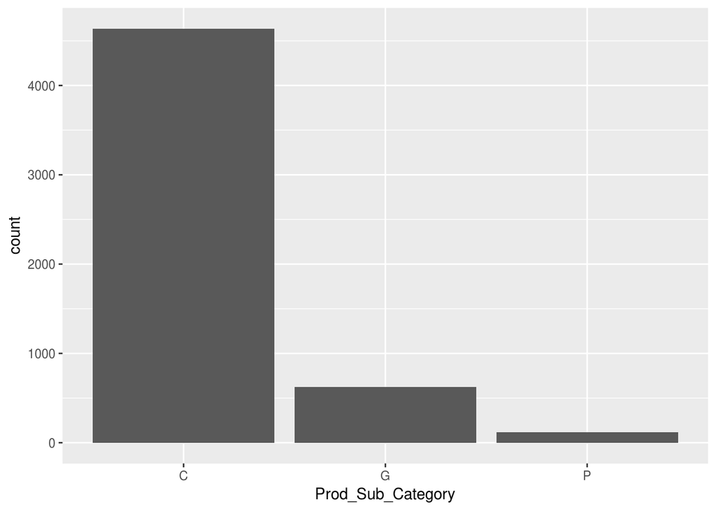

```
##  Prod_Decision_Date
##  Min.   :2011-05-02
##  1st Qu.:2011-08-15
##  Median :2011-11-09
##  Mean   :2011-11-09
##  3rd Qu.:2012-02-09
##  Max.   :2012-04-28
```

[6 more figures not shown]

```r
nameCreditTraining <- names(CreditTraining)
for (varname in nameCreditTraining[-1]) {
  print(summary(dplyr::select(CreditTraining, one_of(varname))))
  NbNa <-sum(is.na(CreditTraining[[varname]]));
  if (NbNa >0) {
    writeLines(strwrap(paste("\n",varname,"has",NbNa, "NA")))
  }
  print(qplot(data = CreditTraining, get(varname), xlab = varname))
}
```

We can spot a few issues in some variables:

- `Customer_Open_Date`: a strange peak,
- `Number_Of_Dependant`: 2 NAs (Not Available) and a strange 20 value,
- `Net_Annual_Income`: 2 NAs and some strange small and large values,
- `Years_At_Business`: 2 NAs and a strange 98 value,
- `Prod_Closed_Date`: 4206 NAs!
5. Provide a quick fix for the NAs (except those in `Prod_Closed_Date`) that replace the values by the median or the mode.

```r
ComputeMedOrMod <- function(x) {
  if (is.factor(x)) {
    y=levels(x)[which.max(table(x))]
  }
  else
  {
    y=median(x,na.rm=TRUE)
  }
  return(y)
}

NAvalue=list()
for (name in names(CreditTraining)) {
  NAvalue[[name]]=ComputeMedOrMod(CreditTraining[[name]])
}
NAvalue[["Prod_Closed_Date"]] <- NULL

Fix_NA <- function(Credit, NAvalue. = NAvalue) {
  for (name  in names(NAvalue.)) {
    Credit[[name]][is.na(Credit[[name]])]=unlist(NAvalue.[[name]])
  }
  Credit
}
CreditTraining <- Fix_NA(CreditTraining)
CreditTesting <- Fix_NA(CreditTesting)
```

6. Adding a dummy variable for `Prod_Closed_Date`

```r
Fix_Prod_Closed_Date <- function(Credit) {
  Credit <- dplyr::mutate(Credit, Prod_Closed_Date_NA = is.na(Prod_Closed_Date))
  Credit[["Prod_Closed_Date"]][Credit$Prod_Closed_Date_NA] = max(Credit[["Prod_Closed_Date"]], na.rm = TRUE)
  Credit
}
CreditTraining <- Fix_Prod_Closed_Date(CreditTraining)
CreditTesting <- Fix_Prod_Closed_Date(CreditTesting)
```

7. Explore visually the dependency between `Y` and the other variables.

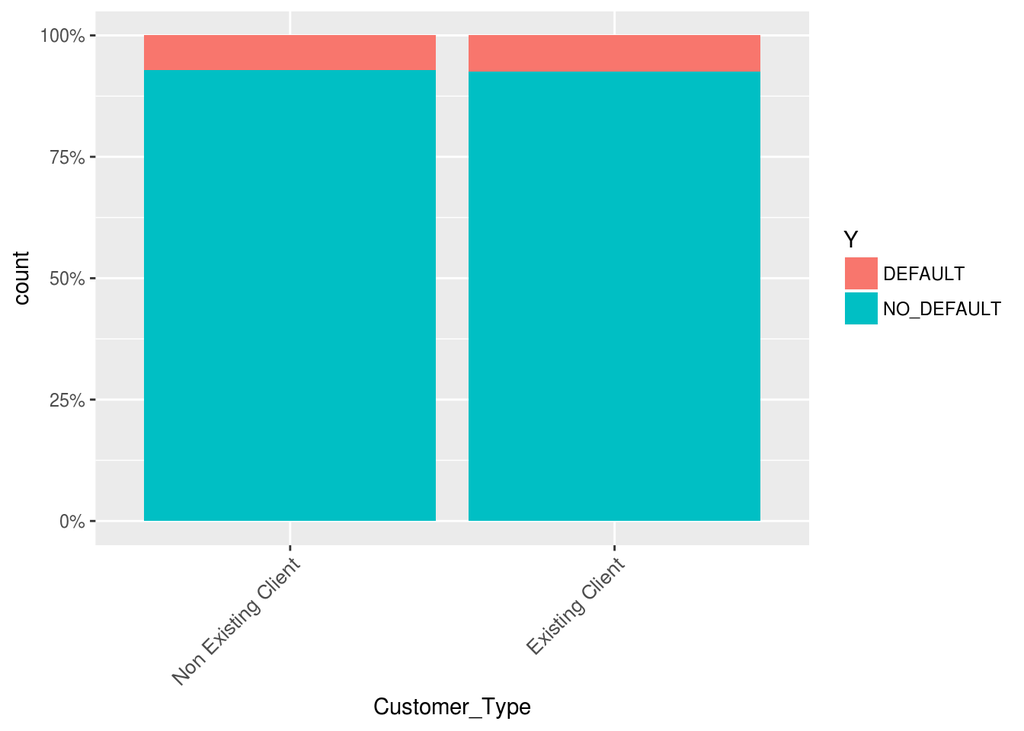

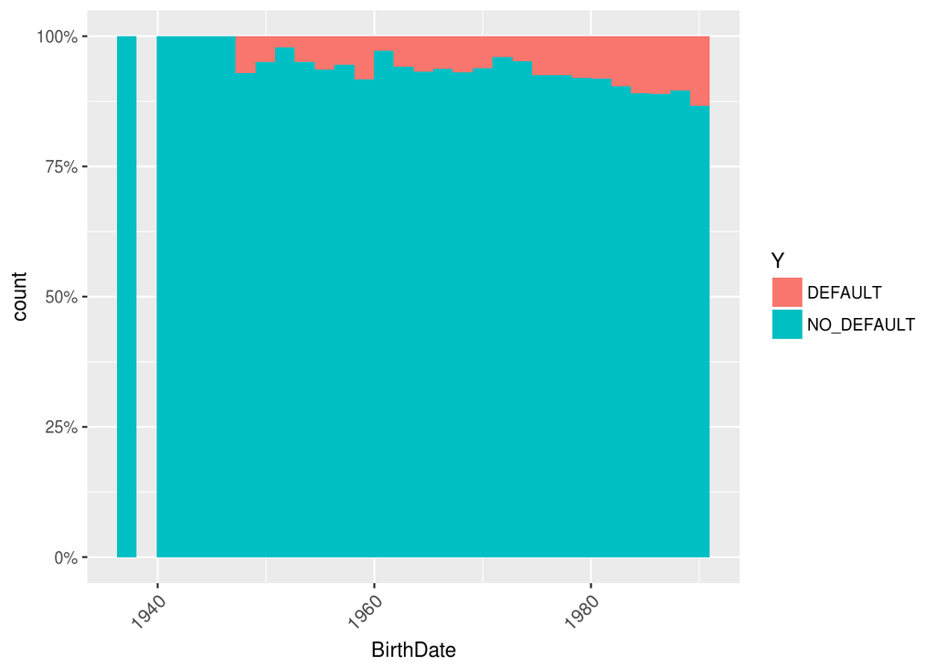

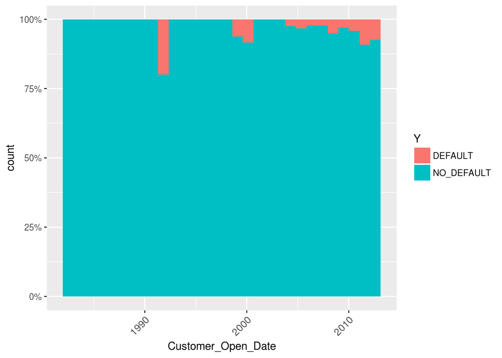

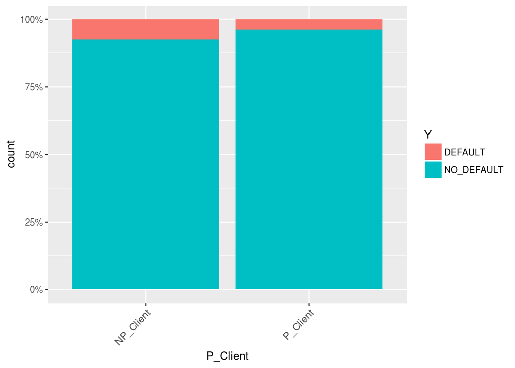

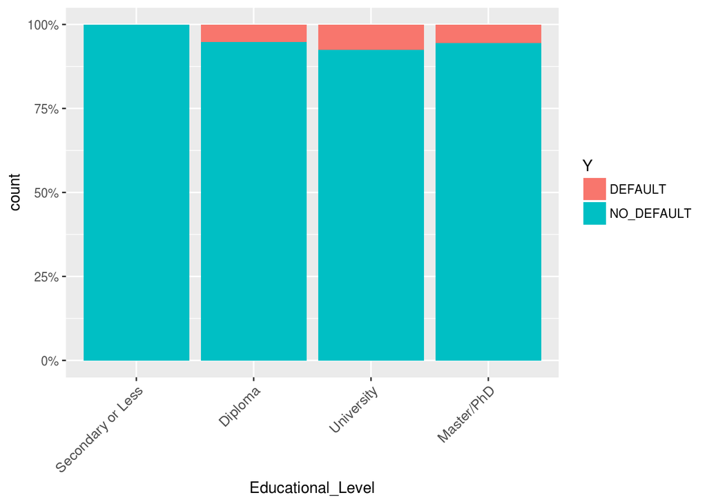

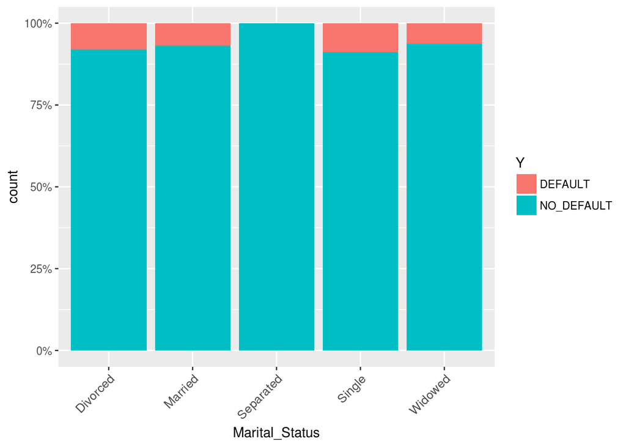

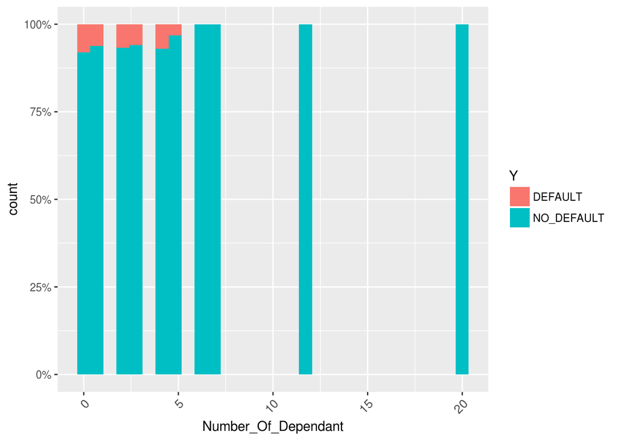

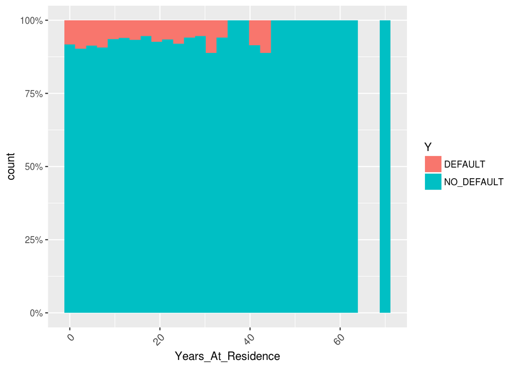

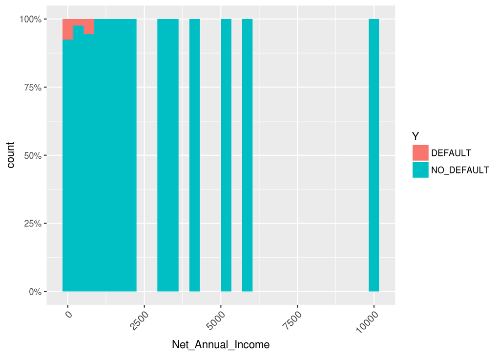

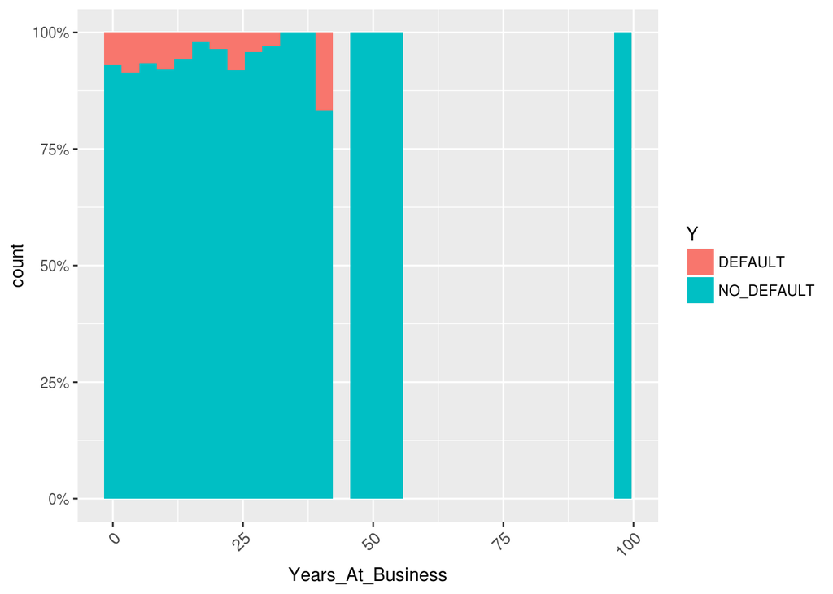

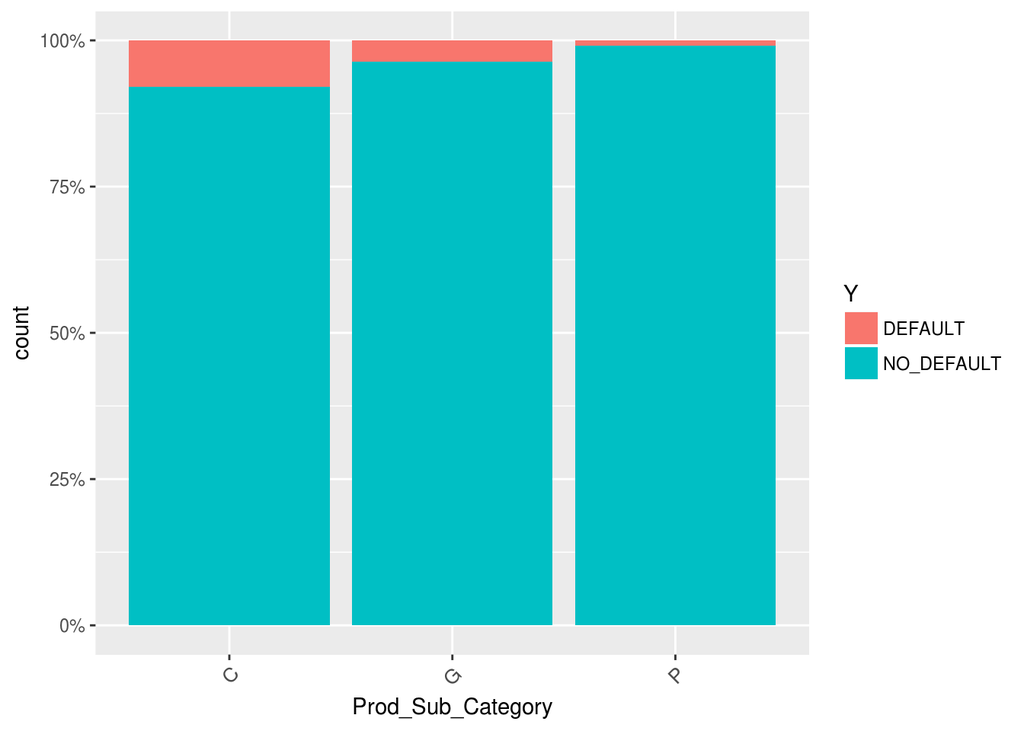

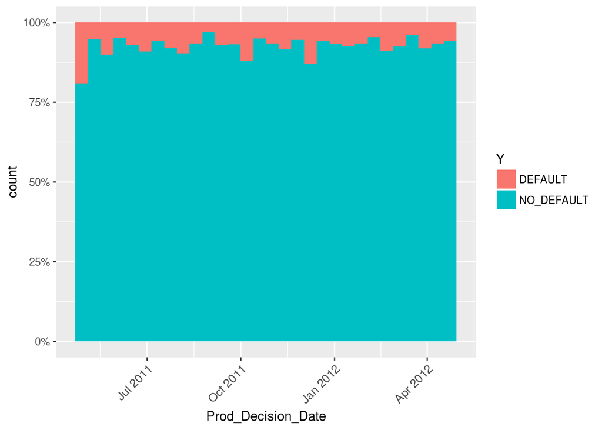

[6 more figures not shown]

```r
library("scales")
nameCreditTraining <- names(CreditTraining)
for (varname in nameCreditTraining[-c(1,2)]) {
  p <- ggplot(data = CreditTraining, aes(x = get(varname), fill = Y)) + xlab(varname)
  switch(class(CreditTraining[[varname]]),
  logical = {p <- p + geom_bar(position = "fill")},
  numeric = {p <- p + geom_histogram(position = "fill")},
  Date = {p <- p + geom_histogram(position = "fill")},
  factor = {p <- p + geom_bar(position = "fill")},
  character = {p <- p + geom_bar(position = "fill")})

  print (p + scale_y_continuous(label = percent_format())    +  theme(axis.text.x =
            element_text(size  = 10,
                         angle = 45,
                         hjust = 1,
                         vjust = 1)) )
}
```

8. Remove the `Id_Customer` which is useless in prediction

```r
CreditTraining <- dplyr::select(CreditTraining, -Id_Customer)
CreditTesting <- dplyr::select(CreditTesting, -Id_Customer)
```

# caret

**caret** is a package which provides a *unified* interface to many *machine learning* packages. Its basic syntax is to `train` a predictor for a given *formula* and given *method* from a *dataset*. For instance, if we want to train a logistic regression with the `Y ~ .` formula from the **CreditTraining** dataset, we can use.

```r
library(caret)
CreditGlm <- train(Y ~ ., data = CreditTraining, method = "glm", metric = "Accuracy")
CreditGlm
```

```
## Generalized Linear Model
##
## 5380 samples
##   18 predictor
##    2 classes: 'DEFAULT', 'NO_DEFAULT'
##
## No pre-processing
## Resampling: Bootstrapped (25 reps)
## Summary of sample sizes: 5380, 5380, 5380, 5380, 5380, 5380, ...
## Resampling results:
##
##   Accuracy   Kappa
##   0.9487446  0.5792294
```

**caret** computes by default the accuracy of the classifier using 25 repetitions of a boostrap resampling scheme. Once the predictor has been trained, it can be used to predict the labels.

```r
PredGlm <- predict(CreditGlm, newdata = CreditTraining)
head(PredGlm)
```

```
## [1] NO_DEFAULT NO_DEFAULT NO_DEFAULT DEFAULT    NO_DEFAULT NO_DEFAULT
## Levels: DEFAULT NO_DEFAULT
```

```r
PredGlm_test <- predict(CreditGlm, newdata = CreditTesting)
ProbGlm <- predict(CreditGlm, newdata = CreditTraining, type = "prob")
head(ProbGlm)
```

```
##       DEFAULT NO_DEFAULT
## 1 0.013925745  0.9860743
## 2 0.001604399  0.9983956
## 3 0.014061289  0.9859387
## 4 0.837221103  0.1627789
## 5 0.012099302  0.9879007
## 6 0.002728081  0.9972719
```

**caret** is quite versatile and one can specify accurately the way the accuracy is computed. For instance, one can impose a V-folds Cross Validation strategy with $V=5$ using the ‘trainControl’.

```r
trControlCV <- trainControl(method = "CV",
                          number = 5)
CreditGlm <- train(Y ~ ., data = CreditTraining, method = "glm",
                   trControl = trControlCV)
CreditGlm
```

```
## Generalized Linear Model
##
## 5380 samples
##   18 predictor
##    2 classes: 'DEFAULT', 'NO_DEFAULT'
##
## No pre-processing
## Resampling: Cross-Validated (5 fold)
## Summary of sample sizes: 4303, 4304, 4304, 4305, 4304
## Resampling results:
##
##   Accuracy   Kappa
##   0.9509299  0.5955802
```

```r
PredGlm <- predict(CreditGlm, newdata = CreditTraining)
head(PredGlm)
```

```
## [1] NO_DEFAULT NO_DEFAULT NO_DEFAULT DEFAULT    NO_DEFAULT NO_DEFAULT
## Levels: DEFAULT NO_DEFAULT
```

```r
ProbGlm <- predict(CreditGlm, newdata = CreditTraining, type = "prob")
head(ProbGlm)
```

```
##       DEFAULT NO_DEFAULT
## 1 0.013925745  0.9860743
## 2 0.001604399  0.9983956
## 3 0.014061289  0.9859387
## 4 0.837221103  0.1627789
## 5 0.012099302  0.9879007
## 6 0.002728081  0.9972719
```

We provide now two functions that will be useful to compare differents models: the first one extract the accuracies for all the folds for a given model and the second one compute the average accuracy for each models.

```r
ErrsCaret <- function(model, name) {
  Errs <- data.frame(model$resample)
  dplyr::mutate(Errs, model = name)
}

ErrCaretAccuracy <- function(Errs) {
  Errs <- group_by(Errs, model)
  cbind(dplyr::summarize(Errs, mAccuracy = mean(Accuracy, na.rm = TRUE), mKappa = mean(Kappa, na.rm = TRUE),
                             sdAccuracy = sd(Accuracy, na.rm = TRUE), sdKappa = sd(Kappa, na.rm = TRUE)))
}

ErrsGlm <- ErrsCaret(CreditGlm, "Glm")
ErrsGlm
```

```
##    Accuracy     Kappa Resample model
## 1 0.9461467 0.5631137    Fold1   Glm
## 2 0.9516729 0.5979478    Fold2   Glm
## 3 0.9488848 0.5883302    Fold3   Glm
## 4 0.9488372 0.5476939    Fold4   Glm
## 5 0.9591078 0.6808155    Fold5   Glm
```

```r
ErrGlm <- ErrCaretAccuracy(ErrsGlm)
ErrGlm
```

```
##   model mAccuracy    mKappa  sdAccuracy    sdKappa
## 1   Glm 0.9509299 0.5955802 0.004971697 0.05164879
```

**caret** can use any **foreach** parallelization package (for instance **doFuture**) to compute in parallel all the error estimates.

```r
system.time(train(Y ~ ., data = CreditTraining, method = "glm",
                   trControl = trControlCV))
```

```
##    user  system elapsed
##   1.668   0.002   1.682
```

```r
library("doFuture")
registerDoFuture()
plan(multiprocess)
system.time(train(Y ~ ., data = CreditTraining, method = "glm",
                   trControl = trControlCV))
```

```
##    user  system elapsed
##   1.940   0.230   2.535
```

Finally, we show how to obtain a ROC curve (and to compute the AUC) for a given classifier using the package **pROC**.

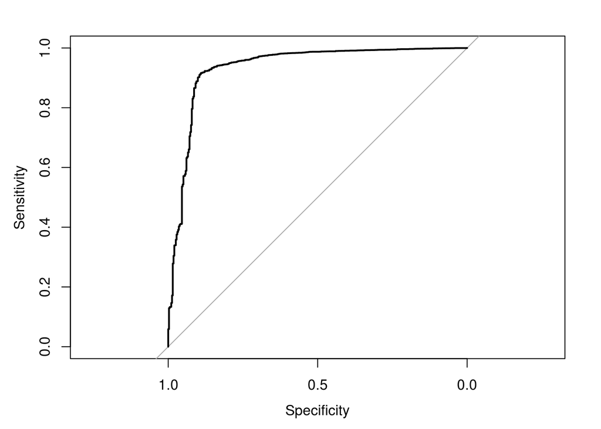

```r
library(pROC)
GlmROC <- roc(CreditTraining[["Y"]], ProbGlm[[1]])
plot(GlmROC)
```

```r
auc(GlmROC)
```

```
## Area under the curve: 0.9344
```

We propose a **ggplot2** interface to obtain *nice* ROC curve.

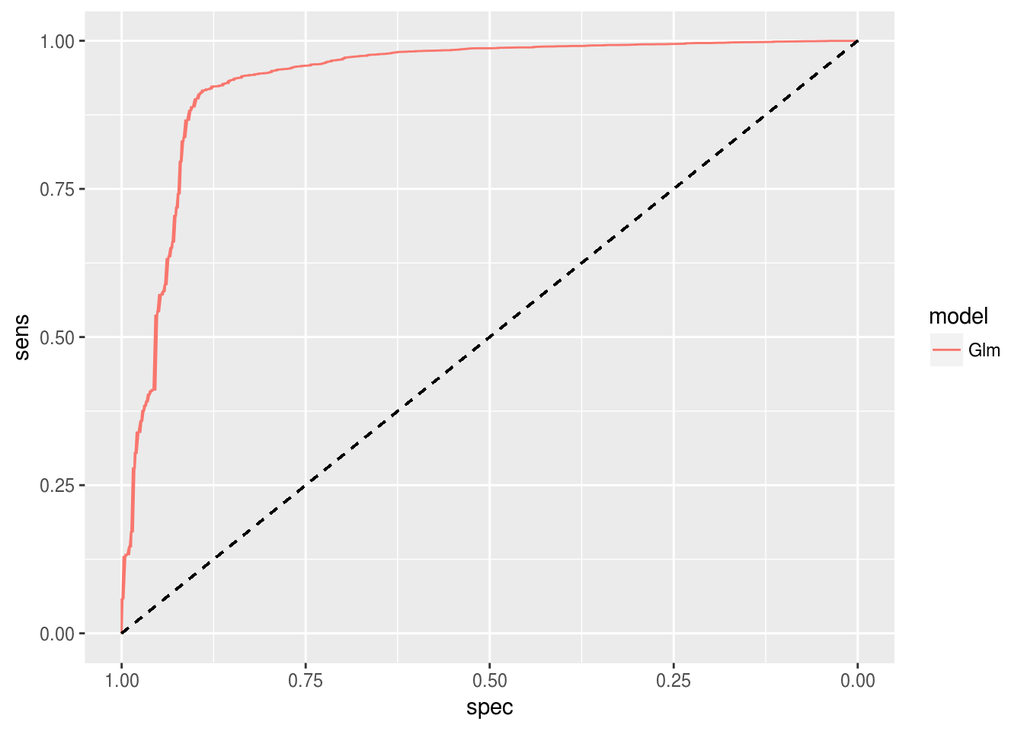

```r
ToROCDF <- function(ROC, name) {
ROCDF <- data.frame(spec = ROC[["specificities"]], sens = ROC[["sensitivities"]], model = name)
}

GlmROCDF <- ToROCDF(GlmROC, "Glm")

PlotROCDF <- function(ROCDF) {
  ggplot(data = ROCDF, aes(x = spec, y = sens, color = model)) + geom_line() + scale_x_reverse() +
    geom_segment(aes(x = 0, y = 1, xend = 1, yend = 0), linetype = 2, color = "black")

}
PlotROCDF(GlmROCDF)
```

When the *method* used has parameters, **caret** choose a grid of values and conducts an automatic optimization.

```r
CreditGlmnet <- train(Y ~ ., data = CreditTraining, method = "glmnet",
                   trControl = trControlCV)
CreditGlmnet
```

```
## glmnet
##
## 5380 samples
##   18 predictor
##    2 classes: 'DEFAULT', 'NO_DEFAULT'
##
## No pre-processing
## Resampling: Cross-Validated (5 fold)
## Summary of sample sizes: 4304, 4303, 4304, 4305, 4304
## Resampling results across tuning parameters:
##
##   alpha  lambda        Accuracy   Kappa
##   0.10   0.0002566701  0.9492561  0.5810645
##   0.10   0.0025667013  0.9479554  0.5551953
##   0.10   0.0256670127  0.9427502  0.4108064
##   0.55   0.0002566701  0.9490701  0.5791333
##   0.55   0.0025667013  0.9485132  0.5547240
##   0.55   0.0256670127  0.9373601  0.3240278
##   1.00   0.0002566701  0.9488846  0.5745571
##   1.00   0.0025667013  0.9483268  0.5460512
##   1.00   0.0256670127  0.9302984  0.1507712
##
## Accuracy was used to select the optimal model using  the largest value.
## The final values used for the model were alpha = 0.1 and lambda
##  = 0.0002566701.
```

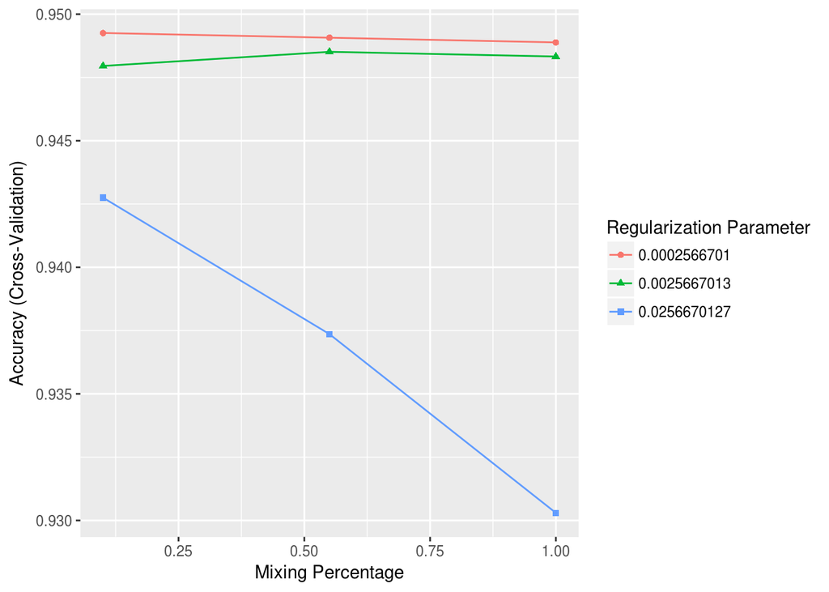

```r
ggplot(CreditGlmnet)
```

Note that the initial grid uses only 3 different values by parameters and is not always well chosen. This grid can be modified in the ‘train’ function parameters.

```r
CreditGlmnet <- train(Y ~ ., data = CreditTraining, method = "glmnet",
                   trControl = trControlCV,
                   tuneGrid  =  expand.grid(alpha = exp(seq(-8,0, length.out = 10)),
                                          lambda = exp(seq(-8,0, length.out = 10))))
CreditGlmnet
```

```
## glmnet
##
## 5380 samples
##   18 predictor
##    2 classes: 'DEFAULT', 'NO_DEFAULT'
##
## No pre-processing
## Resampling: Cross-Validated (5 fold)
## Summary of sample sizes: 4305, 4304, 4304, 4304, 4303
## Resampling results across tuning parameters:
##
##   alpha         lambda        Accuracy   Kappa
##   0.0003354626  0.0003354626  0.9464692  0.49629926
##   0.0003354626  0.0008159878  0.9464692  0.49629926
##   0.0003354626  0.0019848296  0.9464692  0.49629926
##   0.0003354626  0.0048279500  0.9464692  0.49629926
##   0.0003354626  0.0117436285  0.9464692  0.49629926
##   0.0003354626  0.0285655008  0.9431227  0.41723015
##   0.0003354626  0.0694834512  0.9358732  0.25922833
##   0.0003354626  0.1690133154  0.9278812  0.03500451
##   0.0003354626  0.4111122905  0.9269518  0.00000000
##   0.0003354626  1.0000000000  0.9269518  0.00000000
##   0.0008159878  0.0003354626  0.9464692  0.49629926
##   0.0008159878  0.0008159878  0.9464692  0.49629926
##   0.0008159878  0.0019848296  0.9464692  0.49629926
##   0.0008159878  0.0048279500  0.9464692  0.49629926
##   0.0008159878  0.0117436285  0.9464692  0.49629926
##   0.0008159878  0.0285655008  0.9431227  0.41723015
##   0.0008159878  0.0694834512  0.9358732  0.25922833
##   0.0008159878  0.1690133154  0.9276953  0.03077547
##   0.0008159878  0.4111122905  0.9269518  0.00000000
##   0.0008159878  1.0000000000  0.9269518  0.00000000
##   0.0019848296  0.0003354626  0.9479554  0.53174321
##   0.0019848296  0.0008159878  0.9479554  0.53174321
##   0.0019848296  0.0019848296  0.9479554  0.53174321
##   0.0019848296  0.0048279500  0.9479554  0.53174321
##   0.0019848296  0.0117436285  0.9457256  0.49372974
##   0.0019848296  0.0285655008  0.9429366  0.41445952
##   0.0019848296  0.0694834512  0.9360593  0.25999302
##   0.0019848296  0.1690133154  0.9276953  0.03077547
```

[output cut: 61 more lines]

```
##   0.4111122905  1.0000000000  0.9269518  0.00000000
##   1.0000000000  0.0003354626  0.9479555  0.56120713
##   1.0000000000  0.0008159878  0.9492568  0.56958475
##   1.0000000000  0.0019848296  0.9492563  0.55553288
##   1.0000000000  0.0048279500  0.9477709  0.51712862
##   1.0000000000  0.0117436285  0.9399637  0.38797956
##   1.0000000000  0.0285655008  0.9291825  0.11357687
##   1.0000000000  0.0694834512  0.9269518  0.00000000
##   1.0000000000  0.1690133154  0.9269518  0.00000000
##   1.0000000000  0.4111122905  0.9269518  0.00000000
##   1.0000000000  1.0000000000  0.9269518  0.00000000
##
## Accuracy was used to select the optimal model using  the largest value.
## The final values used for the model were alpha = 0.0285655 and lambda
##  = 0.0003354626.
```

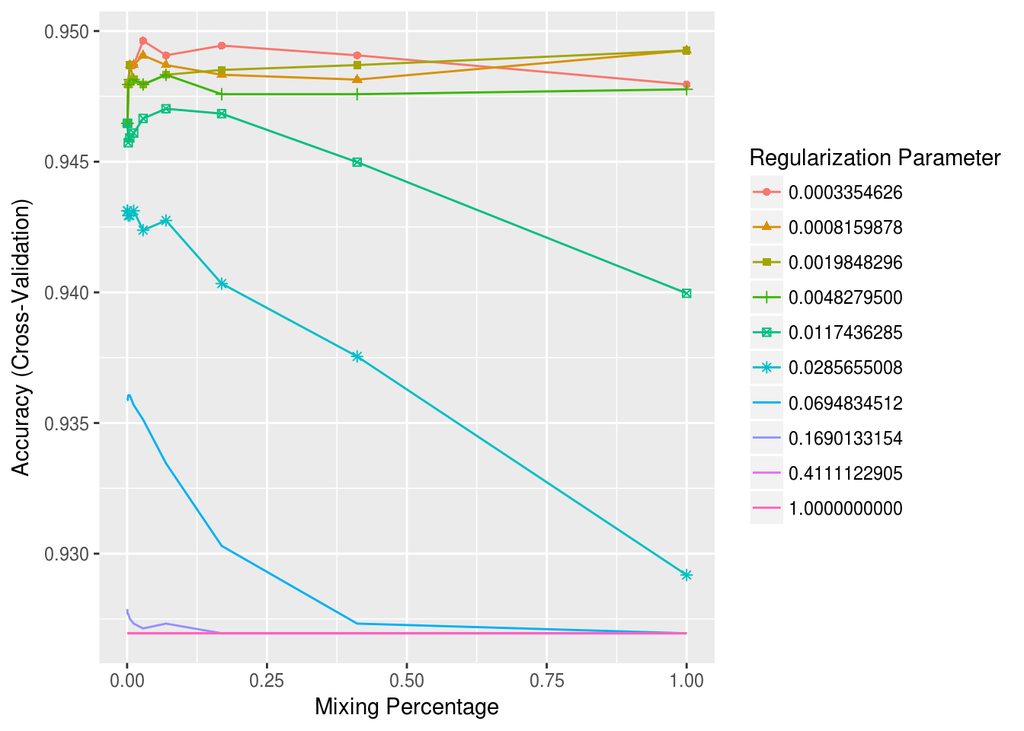

```r
ggplot(CreditGlmnet)
```

Using ‘resamples’, or our own functions, we can compare the different models.

```r
summary(resamples(list(Glm = CreditGlm, Glmnet = CreditGlmnet)))
```

```
##
## Call:
## summary.resamples(object = resamples(list(Glm = CreditGlm, Glmnet
##  = CreditGlmnet)))
##
## Models: Glm, Glmnet
## Number of resamples: 5
##
## Accuracy
##             Min.   1st Qu.    Median      Mean   3rd Qu.      Max. NA's
## Glm    0.9461467 0.9488372 0.9488848 0.9509299 0.9516729 0.9591078    0
## Glmnet 0.9433086 0.9460967 0.9489322 0.9496288 0.9516279 0.9581784    0
##
## Kappa
##             Min.   1st Qu.    Median      Mean   3rd Qu.      Max. NA's
## Glm    0.5476939 0.5631137 0.5883302 0.5955802 0.5979478 0.6808155    0
## Glmnet 0.5198868 0.5547928 0.5661933 0.5790263 0.5868868 0.6673719    0
```

```r
Errs <- ErrsCaret(CreditGlm, "Glm")
Errs <- rbind(Errs, ErrsCaret(CreditGlmnet, "Glmnet"))
Errs
```

```
##     Accuracy     Kappa Resample  model
## 1  0.9461467 0.5631137    Fold1    Glm
## 2  0.9516729 0.5979478    Fold2    Glm
## 3  0.9488848 0.5883302    Fold3    Glm
## 4  0.9488372 0.5476939    Fold4    Glm
## 5  0.9591078 0.6808155    Fold5    Glm
## 6  0.9516279 0.5868868    Fold1 Glmnet
## 7  0.9489322 0.5661933    Fold5 Glmnet
## 8  0.9433086 0.5547928    Fold3 Glmnet
## 9  0.9460967 0.5198868    Fold4 Glmnet
## 10 0.9581784 0.6673719    Fold2 Glmnet
```

```r
Err <- ErrCaretAccuracy(Errs)
Err
```

```
##    model mAccuracy    mKappa  sdAccuracy    sdKappa
## 1    Glm 0.9509299 0.5955802 0.004971697 0.05164879
## 2 Glmnet 0.9496288 0.5790263 0.005700868 0.05503674
```

Finally, all the optimization can be performed using a different paramater than the accuracy, for instance the auc, by specifying it in the ‘trainControl’.

```r
trControlCVROC <- trainControl(method = "CV",
                          number = 5,
                          classProbs = TRUE,
                          summaryFunction = twoClassSummary)
CreditGlmROC <- train(Y ~ ., data = CreditTraining, method = "glm",
                   trControl = trControlCVROC)
CreditGlmROC
```

```
## Generalized Linear Model
##
## 5380 samples
##   18 predictor
##    2 classes: 'DEFAULT', 'NO_DEFAULT'
##
## No pre-processing
## Resampling: Cross-Validated (5 fold)
## Summary of sample sizes: 4304, 4303, 4305, 4304, 4304
## Resampling results:
##
##   ROC        Sens       Spec
##   0.9146875  0.5341772  0.9823551
```

```r
CreditGlmnetROC <- train(Y ~ ., data = CreditTraining, method = "glmnet",
                   trControl = trControlCVROC,
                   tuneGrid  =  expand.grid(alpha = exp(seq(-8,0, length.out = 10)),
                                          lambda = exp(seq(-8,0, length.out = 10))))
CreditGlmnetROC
```

```
## glmnet
##
## 5380 samples
##   18 predictor
##    2 classes: 'DEFAULT', 'NO_DEFAULT'
##
## No pre-processing
## Resampling: Cross-Validated (5 fold)
## Summary of sample sizes: 4304, 4303, 4304, 4305, 4304
## Resampling results across tuning parameters:
##
##   alpha         lambda        ROC        Sens         Spec
##   0.0003354626  0.0003354626  0.9290783  0.407237910  0.9893699
##   0.0003354626  0.0008159878  0.9290783  0.407237910  0.9893699
##   0.0003354626  0.0019848296  0.9290783  0.407237910  0.9893699
##   0.0003354626  0.0048279500  0.9290783  0.407237910  0.9893699
##   0.0003354626  0.0117436285  0.9290783  0.407237910  0.9893699
##   0.0003354626  0.0285655008  0.9287385  0.308081792  0.9929795
##   0.0003354626  0.0694834512  0.9267663  0.162901655  0.9963898
##   0.0003354626  0.1690133154  0.9229621  0.022947095  0.9993982
##   0.0003354626  0.4111122905  0.9193208  0.000000000  1.0000000
##   0.0003354626  1.0000000000  0.9166358  0.000000000  1.0000000
##   0.0008159878  0.0003354626  0.9290807  0.407237910  0.9893699
##   0.0008159878  0.0008159878  0.9290807  0.407237910  0.9893699
##   0.0008159878  0.0019848296  0.9290807  0.407237910  0.9893699
##   0.0008159878  0.0048279500  0.9290807  0.407237910  0.9893699
##   0.0008159878  0.0117436285  0.9290807  0.407237910  0.9893699
##   0.0008159878  0.0285655008  0.9287334  0.308081792  0.9929795
##   0.0008159878  0.0694834512  0.9267663  0.162901655  0.9963898
##   0.0008159878  0.1690133154  0.9229776  0.022947095  0.9993982
##   0.0008159878  0.4111122905  0.9193412  0.000000000  1.0000000
##   0.0008159878  1.0000000000  0.9166101  0.000000000  1.0000000
##   0.0019848296  0.0003354626  0.9289637  0.450340798  0.9861613
##   0.0019848296  0.0008159878  0.9289637  0.450340798  0.9861613
##   0.0019848296  0.0019848296  0.9289637  0.450340798  0.9861613
##   0.0019848296  0.0048279500  0.9289637  0.450340798  0.9861613
##   0.0019848296  0.0117436285  0.9290656  0.417396949  0.9883669
##   0.0019848296  0.0285655008  0.9287413  0.308081792  0.9929795
##   0.0019848296  0.0694834512  0.9267943  0.162901655  0.9963898
##   0.0019848296  0.1690133154  0.9229138  0.022947095  0.9993982
```

[output cut: 61 more lines]

```
##   0.4111122905  1.0000000000  0.5000000  0.000000000  1.0000000
##   1.0000000000  0.0003354626  0.9289025  0.534404414  0.9823509
##   1.0000000000  0.0008159878  0.9294080  0.508828302  0.9829525
##   1.0000000000  0.0019848296  0.9306512  0.475787082  0.9853591
##   1.0000000000  0.0048279500  0.9298848  0.419831224  0.9879657
##   1.0000000000  0.0117436285  0.9207343  0.295163908  0.9899717
##   1.0000000000  0.0285655008  0.9223322  0.078870497  0.9967908
##   1.0000000000  0.0694834512  0.9002671  0.000000000  1.0000000
##   1.0000000000  0.1690133154  0.5000000  0.000000000  1.0000000
##   1.0000000000  0.4111122905  0.5000000  0.000000000  1.0000000
##   1.0000000000  1.0000000000  0.5000000  0.000000000  1.0000000
##
## ROC was used to select the optimal model using  the largest value.
## The final values used for the model were alpha = 0.4111123 and lambda
##  = 0.00482795.
```

1. Using the page http://topepo.github.io/caret/modelList.html, try the some of the methods seen during the lecture (Naive Bayes, k-NN, SVM, NN, Bagging, Random Forest, AdaBoost…).

```r
CreditNB <-  train(Y ~ ., data = CreditTraining, method = "nb",
                    trControl = trControlCV, tuneGrid = expand.grid(fL = 10, usekernel = c(TRUE, FALSE), adjust = TRUE)
                    )
Errs <- rbind(Errs, ErrsCaret(CreditNB, "NB"))
```

```r
CreditKNN <-  train(Y ~ ., data = CreditTraining, method = "knn",
                   trControl = trControlCV)
Errs <- rbind(Errs, ErrsCaret(CreditKNN, "KNN"))
```

```r
CreditSVM <- train(Y ~ ., data = CreditTraining, method = "svmLinear",
                   trControl = trControlCV)
Errs <- rbind(Errs, ErrsCaret(CreditSVM, "SVM"))

CreditSVMPoly <- train(Y ~ ., data = CreditTraining, method = "svmPoly",
                   trControl = trControlCV)
Errs <- rbind(Errs, ErrsCaret(CreditSVMPoly, "SVMPoly"))

CreditSVMRadial <- train(Y ~ ., data = CreditTraining, method = "svmRadial",
                   trControl = trControlCV)
Errs <- rbind(Errs, ErrsCaret(CreditSVMPoly, "SVMRadial"))
```

```r
CreditNN <- train(Y ~ ., data = CreditTraining, method = "nnet",
                   trControl = trControlCV)
Errs <- rbind(Errs, ErrsCaret(CreditNN, "NN"))
```

```r
CreditBagging <- train(Y ~ ., data = CreditTraining, method = "treebag",
                   trControl = trControlCV)
Errs <- rbind(Errs, ErrsCaret(CreditBagging, "Bagging"))

CreditRF <- train(Y ~ ., data = CreditTraining, method = "rf",
                   trControl = trControlCV)
Errs <- rbind(Errs, ErrsCaret(CreditRF, "RF"))

CreditC5 <- train(Y ~ ., data = CreditTraining, method = "C5.0",
                   trControl = trControlCV)
Errs <- rbind(Errs, ErrsCaret(CreditC5, "C5.0"))
```

```r
CreditxgbLinear <- train(Y ~ ., data = CreditTraining, method = "xgbLinear",
                   trControl = trControlCV)
Errs <- rbind(Errs, ErrsCaret(CreditxgbLinear, "Xgboost"))

CreditxgbTree <- train(Y ~ ., data = CreditTraining, method = "xgbTree",
                   trControl = trControlCV)
Errs <- rbind(Errs, ErrsCaret(CreditxgbTree, "Xgboost Tree"))
```

```r
Err <- ErrCaretAccuracy(Errs)
Err
```

```
##           model mAccuracy    mKappa   sdAccuracy    sdKappa
## 1       Bagging 0.9505571 0.6017333 0.0060760701 0.04331224
## 2          C5.0 0.9570609 0.6543027 0.0046478365 0.02954942
## 3           Glm 0.9509299 0.5955802 0.0049716968 0.05164879
## 4        Glmnet 0.9496288 0.5790263 0.0057008680 0.05503674
## 5           KNN 0.9289971 0.2542723 0.0024806583 0.04983738
## 6            NB 0.9269518 0.0000000 0.0004795246 0.00000000
## 7            NN 0.9394033 0.5669013 0.0050918492 0.03020801
## 8            RF 0.9533491 0.6218952 0.0084314563 0.07895863
## 9           SVM 0.9457247 0.5138352 0.0106908294 0.16699920
## 10      SVMPoly 0.9457204 0.5233878 0.0115713523 0.15540251
## 11    SVMRadial 0.9457204 0.5233878 0.0115713523 0.15540251
## 12      Xgboost 0.9581776 0.6661889 0.0030961142 0.03613060
## 13 Xgboost Tree 0.9600356 0.6744510 0.0080829754 0.06173572
```

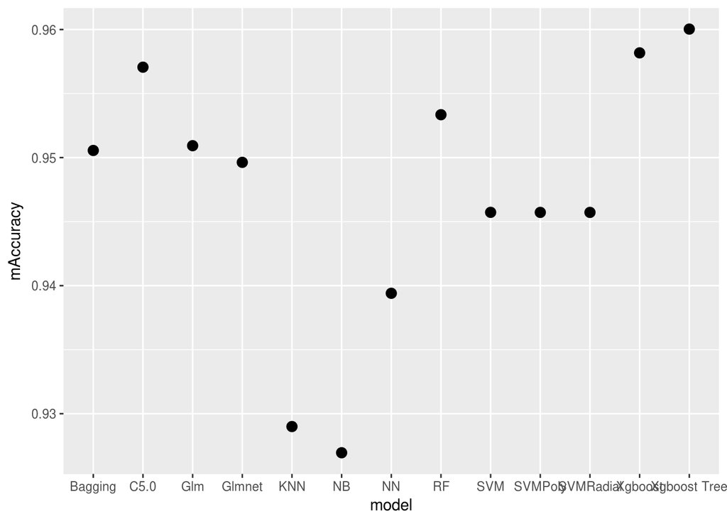

```r
ggplot(data = Err, aes(x = model, y = mAccuracy)) + geom_point(size = 3)
```

2. Find better parameters in the previous methods.
3. Modify the input vectors (apply a function to the income, modify the date so that they are relative to the product decision date,…) to obtain better results?